# PISCES Tutorial

**Authors:** Lukas Vlahos, Pasquale Laise, Andrea Califano  
**Correspondence:** Pasquale Laise and Andrea Califano  
**Contacts:**

- Lukas Vlahos: lv2395@cumc.columbia.edu
- Pasquale Laise: pl2959@cumc.columbia.edu
- Andrea Califano: ac2248@cumc.columbia.edu

### Introduction

The pipeline for Protein Activity Inference in Single Cells (PISCES) is a regulatory-network-based methdology for the analysis of single cell gene expression profiles.

PISCES transforms highly variable and noisy single cell gene expression profiles into robust and reproducible protein activity profiles. PISCES is centered around two key algorithms: the Algorithm for the Reconstruction of Accurate Cellular Networks ARACNe [1]; and the algorithm for Virtual Inference of Protein-activity by Enriched Regulon analysis (VIPER/metaVIPER) [2,3].

Briefly, the ARACNe algorithm is one of the most widely used methods for inferring transcriptional interactions from gene expression data. The VIPER algorithm uses the expression of the ARACNe-inferred regulatory targets of a given protein, such as the targets of a transcription factor (TF), as an accurate reporter of its activity. Typically, PISCES can accurately assess the activity of up to 6000 regulatory proteins from single cell gene expression profiles, significantly increasing the ability to analyze the biological function and relevance of gene products whose mRNAs are undetectable in individual cells (e.g. dropout effect).

### Setup

PISCES is implemented in R and requires the following packages:

- viper (v1.18.1)
- cluster
- ggplot2
- ggpubr
- umap
- pheatmap
- RColorBrewer
- Matrix
- biomaRt
- psych
- MUDAN

**NOTE:** This tutorial assumes the working directoyis set to the folder containing the PISCES repository. Allthe data generated by PISCES will be saved in the same directory. This is not recommended for practical use, and can be changed by specifying full paths when loading or saving in your own applications.

#### Getting started

Start by loading in the PISCES functions as well as the provided test data. Note that this pipeline uses ENSMBL Gene IDs by default:

```r
source('functions/process-utils.R')
source('functions/cluster-functions.R')
source('functions/viper-utils.R')
library(ggplot2)
library(ggpubr)
library(viper)
library(pheatmap)
library(RColorBrewer)
library(MUDAN)
library(umap)
raw.mat <- readRDS('tutorial/pbmc.rds')
```

Alternatively, if the data are in 10x format, you can load the data using the following code (*if the data are already in .rds format, this step does not need to run this for the purposes of the tutorial*):

```r
library(Matrix)
raw.mat <- as.matrix(readMM('data/matrix.mtx'))
genes <- read.table('data/genes.tsv', sep = '\t')
barcodes <- read.table('data/barcodes.tsv', sep = '\t')
colnames(raw.mat) <- barcodes[,1]
rownames(raw.mat) <- genes[,1]
```

We recommend saving intermediate data at each step, since many of these steps will take a considerable amount of time. These saving steps are not including in this tutorial, but can be achieved with the saveRDS function in R.

### PreProcessing

First, the data is analyzed for quality control. Sequencing depth, number of detected genes, saturation, and mitochondrial gene percentage are assessed here. The mitochondrial gene percentage analysis requires a saved .csv with mitochondrial gene names, which is provided for human genes in PISCES (‘mt-geneList.csv’):

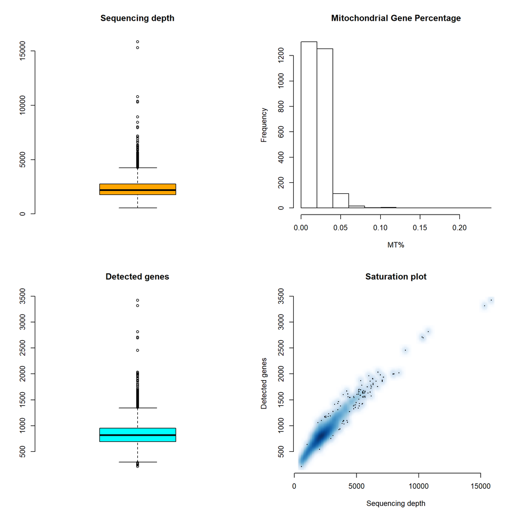

```r
QCPlots(raw.mat, 'mt-geneList.csv')
```

This data is used to preprocess the data in several ways:

- Genes with no expression (zero reads across all cells) are removed
- Cells with less than 1000 UMIs or more than 100000 UMIs can be considered low quality, and are also removed.
- Additionally, if a population of cells has significantly more mitochondrial genes (generally, more than 10%), these cells can be removed with the *MTFilter* function.

The parameters for both the *QCTransform* and *MTFilter* function should be adjusted for your data. Once the data set is filtered, it is normalized using CPM. Finally, a gene expression signature (*rank.mat*) is then generated:

```r
mt.mat <- MTFilter(raw.mat, 'mt-geneList.csv')
```

```
## [1] 2694
```

```r
filt.mat <- QCTransform(mt.mat)
```

```
## [1] "Removed 16106 genes and 147 cells."
```

```r
cpm.mat <- CPMTransform(filt.mat)
rank.mat <- RankTransform(cpm.mat)
```

By default, the gene expression signature is generated by performing a “double rank” transformation, which uses the median gene expression of the data set as an internal reference to compute a gene expression signature on a cell by cell basis.

### 1.1 Single Cell Network Generation

**NOTE:** Because ARACNe takes a considerable amount of time to run, we recommend setting up a cluster-based implementation. For ease-of-use in this tutorial, we have included the networks generated in this analysis within the tutorial. For a detailed tutorial on how to use ARACNe-AP, consult the github here: https://github.com/califano-lab/ARACNe-AP/blob/master/README.md

The default PISCES approach assumes that there are no known cell type annotation in the data set. PISCES will generate an ARACNe network from all the cells. If different cell types in the data set are experimetally defined (e.g. by FACs) and annotated, cell-type specific networks can be generated based on the cell type annotation. However, we recommend proceeding in an unsupervised manner, as the unsupervised analysis can confirm the experimental design and, potentially, identify novel biological findings.

The data must first be saved in a format that is compatible with the Java based ARACNe-AP implementation included in this pipeline:

```r
ARACNeTable(cpm.mat, 'tutorial/pbmc-cpm.tsv')
```

ARACNe should be run independently for each regulator set (TFs, COTFs, and Signaling Proteins). The files containing the lists of the candidate master regulator proteins can be found in the *Modules/ARACNe/* directory for both mouse and human data. The newtwork files generated by ARACNE (.tsv’s) for each set of regulators should be merged in single file (this can be easily done through command line). Finally, the merged .tsv’s and the gene expression matrix from which the network was inferred are combined by VIPER to generate a regulon object with the following command:

```r
RegProcess('tutorial/pbmc_r1-net-final.tsv', cpm.mat, out.dir = 'tutorial/', out.name = 'pbmc_r1-net-')
```

### 1.2 First clustering analysis

Once the ARACNe network has been generated, we can infer protein activity as follows:

```r
r1.net <- readRDS('tutorial/pbmc_r1-net-pruned.rds')
r1.pAct <- viper(rank.mat, r1.net, method = 'none')
```

Single-cell ARACNe networks usually contain fewer regulons than those generated from bulk data due to data sparsity that characterize single cell gene expresion data. However, it is possible to combine single-cell networks with precomputed GTEx bulk networks using the metVIPER algorithm. Briefly, MetaVIPER will identify the GTEX networks that have the best macth with the single cell data, then will use these networks to compute the protein activity only for the proteins whose regulon was not inferred from single cell gene expression profiles (*r1.pAct* object).

**NOTE:** for the purposes of this tutorial, this is an optional step (not required). Because this step uses more than 30 networks, it will take a considerable amount of time and memory to run. We recommend running this step on a cluster system with 32GB of memory or more allocated for any data set with 1000 or more cells. Finally, this step is not relevant for murine data, as the GTEx networks are generated from human RNAseq samples.

```r
r1.gtex <- GTExVIPER(rank.mat, 'GTEx-Nets/')
r1.pAct <- ViperMerge(r1.pAct, r1.gtex)
```

Once the protein activity has been computed, clustering analysis can be performed on the protein activity-based distance matrix This pipeline uses *viperSimilarity* as a distance metric and the *PAM* algorithm for clusterin. Other methods such as K-Means or Louvain clustering can be applied, but we recommend the default implementation (i.e. viper similarity and PAM) as we have extensively tested this approach.

```r
r1.viperDist <- as.dist(viperSimilarity(r1.pAct))
r1.clusts <- PamKRange(r1.viperDist, kmin = 2, kmax = 10)
```

```
## [1] "Clustering with k=2..."
## [1] "Clustering with k=3..."
## [1] "Clustering with k=4..."
## [1] "Clustering with k=5..."
## [1] "Clustering with k=6..."
## [1] "Clustering with k=7..."
## [1] "Clustering with k=8..."
## [1] "Clustering with k=9..."
## [1] "Clustering with k=10..."
```

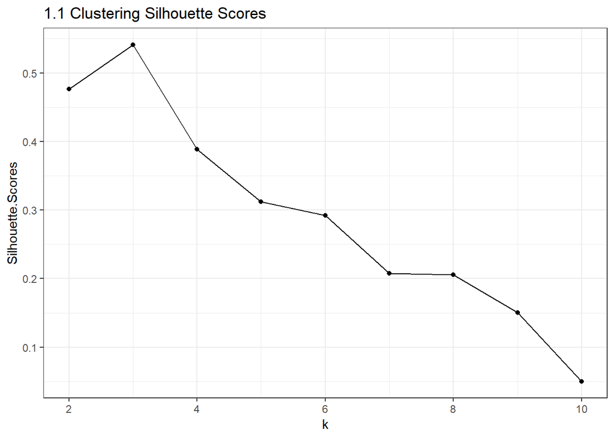

```r
r1.clustSil <- SilScoreEval(r1.clusts, r1.viperDist)
plot.dat <- data.frame('k' = 2:10, 'Silhouette.Scores' = r1.clustSil)
ggplot(plot.dat, aes(x = k, y = Silhouette.Scores)) + geom_point() + geom_line() +
  ggtitle('1.1 Clustering Silhouette Scores') + theme_bw()
```

In order to improve the quality of the ARACNe networks, PISCES can transform single cell gene expression profiles into metacell profiles. The PISCES meta-cell inference algorithm aims at overcoming the sparse nature of single cell data due to dropouts (inefficient mRNA capture) by integrating the expression profiles of cells with similar protein activity profiles within each cluster. This is accomplished by generating a K-nearest neighbor (KNN) graph based on the *viperSimilarity* distance method, then integrating the counts of the K nearest cells. All of these steps can be accomplished with the following command (if you are interested in running these steps seperately in your analysis, there are also stand alone commands for each step):

```r
r1.clustMats <- MakeCMfA(filt.mat, r1.viperDist, clustering = r1.clusts$k3, out.dir = 'tutorial/', out.name = 'pbmc-r1-clusts')
```

### 2.1 Cluster-specific network generation

In the first clustering analysis, PISCES has identified clusters of cells based ona single regulatory model (ARACNe network) inferred from all the data. However, these clusters represent populations of cells with distinct regulatory models (e.g. lineages or cell types) whose identification is essential to accurately infer protein activity. In this step, PISCES infers cluster-specific regulatory networks.

**NOTE:** NOTE: As in the **1.1 Network Generation** step, we have included the ARACNe networks generated in this step within the tutorial.

The procedure for this step is the same as in **1.1 Network Generation**, but must be repeated for each cluster generated in the **1.1 Clustering** step.

### 2.2 Protein activity based clustering analysis

Cluster-specific networks are now used to re-infer protein activity:

```r
# load in networks
c1.net <- readRDS('tutorial/pbmc-r2-c1_pruned.rds')
c2.net <- readRDS('tutorial/pbmc-r2-c2_pruned.rds')
c3.net <- readRDS('tutorial/pbmc-r2-c3_pruned.rds')
# infer protein activity
r2.pAct <- viper(rank.mat, list('c1' = c1.net, 'c2' = c2.net, 'c3' = c3.net), method = 'none')
```

Next, the most representative proteins (i.e. top differentially activated proteins) are selected on a cell-by-cell basis and used for downstream clustering analysis. Clustering analysis is performed using the Louvain method and visualized using a Uniform Manifold Approximation and Projection (UMAP):

```r
r2.cbcMRs <- CBCMRs(r2.pAct) # identify the most representative proteins
r2.pAct.cbc <- r2.pAct[ r2.cbcMRs ,] # filter the protein activity matrix
r2.louvain <- LouvainClust(r2.pAct.cbc) # perform clustering analysis
```

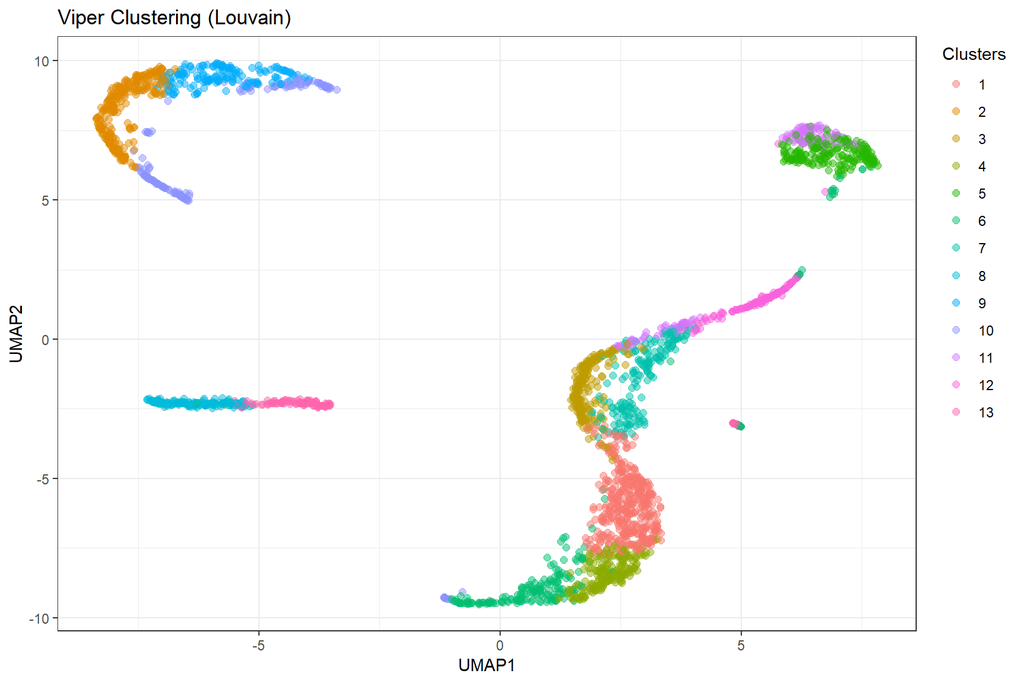

```r
r2.cbcUMAP <- CustomUMAP(r2.pAct.cbc)
ClusterScatter(r2.cbcUMAP, r2.louvain, 'Viper Clustering (Louvain)')
```

### 3.1 Identifying Differentially activated Proteins

Cluster specific differentially activated proteins can now be identified using a bootsrapped T-test. Each cluster is compared against the rest of the data to identify the proteins most specifc to that cluster. Additionally, the data set is converted from ENSG to Gene Names for ease of interpretation:

```r
r2.pAct <- Ensemble2GeneName(r2.pAct)
r2.MRs <- BTTestMRs(r2.pAct, r2.louvain)
```

These master regulators can then be visualized in a heatmap:

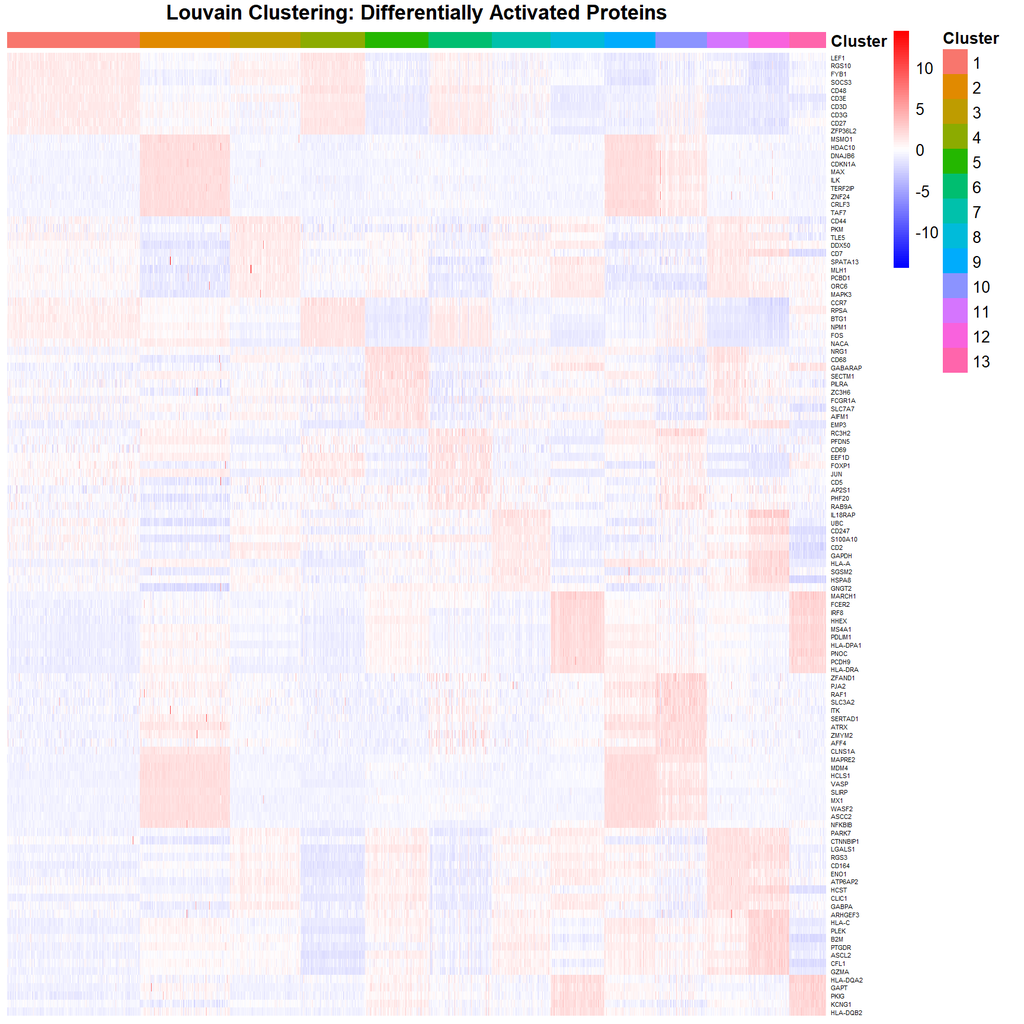

```r
ClusterHeatmap(r2.pAct[ MR_UnWrap(r2.MRs, top = 10) , ], clust = r2.louvain, plotTitle = 'Louvain Clustering: Differentially Activated Proteins')
```

### 3.2 Superimposing Markers

The clusters generated by this pipeline are totally unsupervised by previously defined markers. Nevertheless, investigating how known markers overlay with the clustering can help guide biological insights and guide cell type identification. Here, we overlay a selection of commonly used PBMC markers with the louvain clustering:

[figure not shown]

```r
markers <- c('CCR7', 'CD8A', 'MS4A1', 'PPBP', 'MS4A7', 'IL7R', 'CD14', 'FCER1A', 'FCGR3A')
MarkerGrid(r2.cbcUMAP, r2.louvain, r2.pAct, markers, 'PBMC Marker Activity')
```

### References

1. Lachmann, A., et al., *ARACNe-AP: gene network reverse engineering through adaptive partitioning inference of mutual information*. Bioinformatics, 2016. 32(14): p. 2233-5.
2. Califano, H.D.a.A., *iterClust: Iterative Clustering*. R package version 1.4.0. 2018: https://github.com/hd2326/iterClust.
3. Ding, H., et al., *Quantitative assessment of protein activity in orphan tissues and single cells using the metaVIPER algorithm*. Nat Commun, 2018. 9(1): p. 1471.
4. Rosseeuw, P.J., *Journal of Computational and Applied Mathematics* 20 (1987) 53-65
5. Izenman, A.J., *Modern Multivariate Statistical Techniques. Regression, Classification, and Manifold Learning*. Springer text in statistics, 2008 (Chapter 12)

#### Acknowledgements

Jeremy Dooley - for his advice and expertise in single cell sequencing experiments.  
Hongxu Ding - whose work in the Califano laid the groundwork for the development of this pipeline.  
Evan Paull - for help with software and tutorial development and testing.